# How Past Risk Levels and Pass Rates Can be Used to Predict Future Results

- Show All Code
- Hide All Code
- View Source

Would a Local Chicago Facility Pass a Food Inspection?

Author

Precious C. Igbiki

Published

August 1, 2024

### Abstract

This research project looked at how can previous inspection results and risk levels determine the future results for businesses in the Daycare, Restaurant, Bar, and School sectors? Diving deep into this question can help the food service industry, and any facility susceptible to food inspections, to be aware of how their business practices are affecting the results of their food inspections and by extension their reputation in the community. Going into this project, a hypothesis was made that the past risk levels are a likely determiner of future risk levels. After the creation of a Linear Regression Model as well as a Chi-Square Test, future results were found to be without a doubt dependent on past risk levels and a strong linear correlation was found between past risk levels and present results. Meaning that no matter the change and development a facility can go through, the past risk levels that was assigned to them can continue to affect their current food inspection results. Going to show the importance of maintaining a high standard of food safety from the start.

### Background

In 2022 alone the city of Chicago issued over 6,100 new business licenses. In the same year the percentage of businesses that renewed their license was 84.6% (Chicago Business Bulletin *Year in Review*). Meaning businesses aren’t just starting around the city but also continuing to grow and become apart of the community around them. The Centers for Disease Control and Prevention (CDC) estimates that 1 in 6 Americans will be hospitalized yearly do to food borne illnesses (CDC *Estimates of foodborne illness in the United States*). Considering these truths together it is understandable that a city as large as Chicago, which boasts over 2 million people and thousands of restaurants, want to maintain high standards for any facility that serves food.

For this project the data used is collected from the city of Chicago and is updated on a monthly basis. The research question being looked into is, how can previous inspection results and risk levels determine the future results for businesses in the Daycare, Restaurant, Bar, and School sectors? Before analysis was conducted the hypothesis that previous inspection rates have a significant implication on future results was presumed.

### Results

First to see which facility type would have the most Inspections classified as Risk 1, Risk 2 or Risk 3 graphs that look at specific risks as the primary filter were formed. I quickly realized that restaurants show the largest count of all 4 facility types and because of I knew that whenever I compared different kinds of facilities I had to use proportions

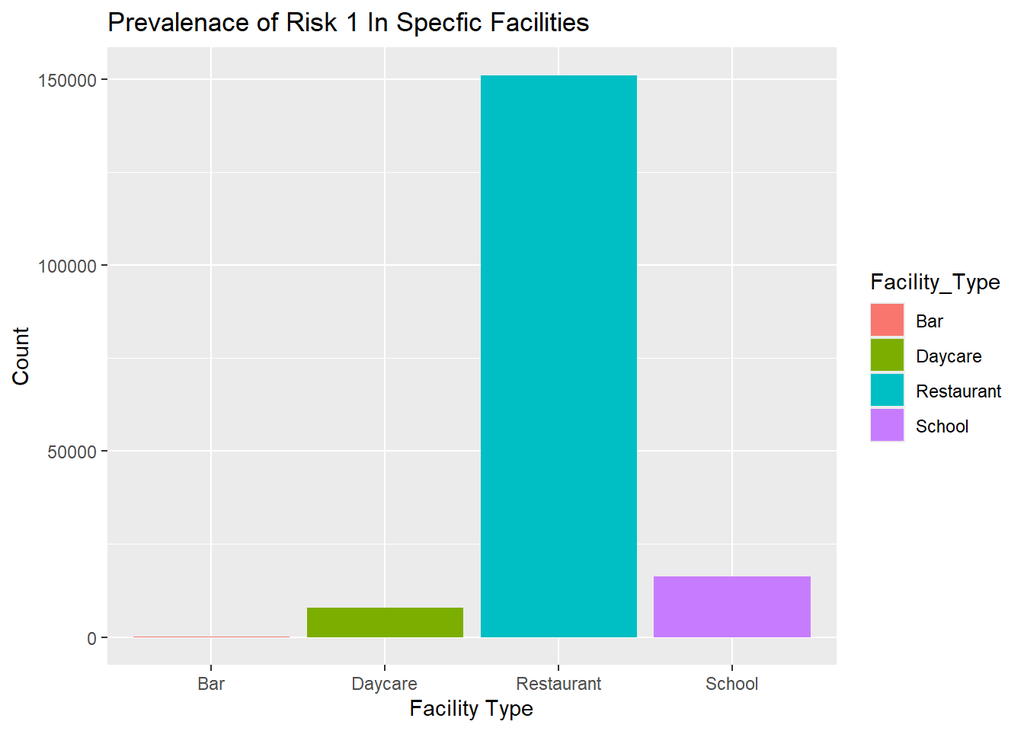

Figure 1: Prevalence of Risk 1 (High) inspections across the four facility types.

```r
#Risk 1
csf_select %>%
  filter(Risk == 'Risk 1 (High)') %>%
  ggplot(aes(Facility_Type, fill = Facility_Type)) +
  geom_bar() +
  labs(title = "Prevalenace of Risk 1 In Specfic Facilities",
       x = 'Facility Type',
       y = 'Count')
```

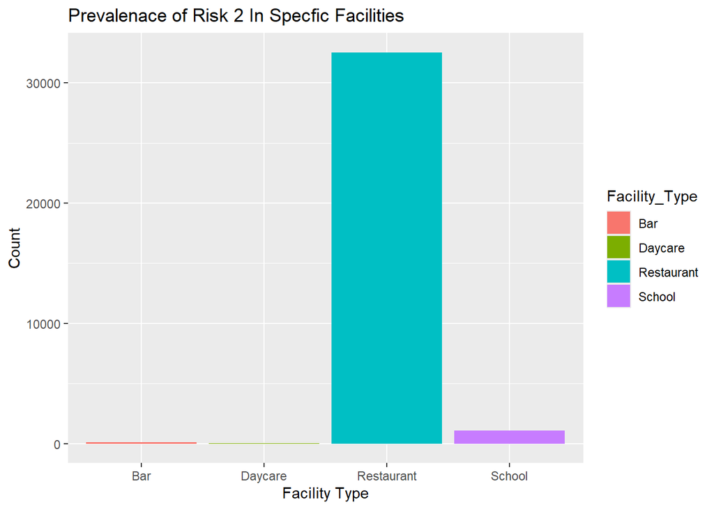

Figure 2: Prevalence of Risk 2 (Medium) inspections across the four facility types.

```r
#Risk #2
csf_select %>%
  filter(Risk == 'Risk 2 (Medium)') %>%
  ggplot(aes(Facility_Type, fill = Facility_Type)) +
  geom_bar() +
  labs(title = "Prevalenace of Risk 2 In Specfic Facilities",
       x = 'Facility Type',
       y = 'Count')
```

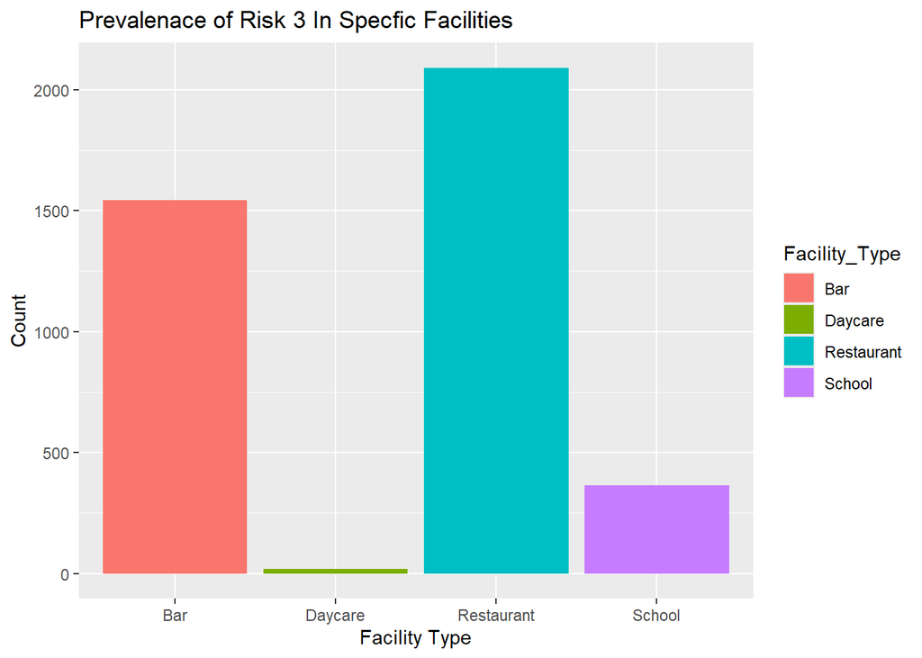

Figure 3: Prevalence of Risk 3 (Low) inspections across the four facility types.

```r
#Risk #3
csf_select %>%
  filter(Risk == 'Risk 3 (Low)') %>%
  ggplot(aes(Facility_Type, fill = Facility_Type)) +
  geom_bar() +
  labs(title = "Prevalenace of Risk 3 In Specfic Facilities",
       x = 'Facility Type',
       y = 'Count')
```

#### Risk Levels Over Time

To see how the distribution of risk levels has been shifting in facilities that actually passed their inspections, I broke the data out by year for daycares and restaurants from 2010 to 2024.

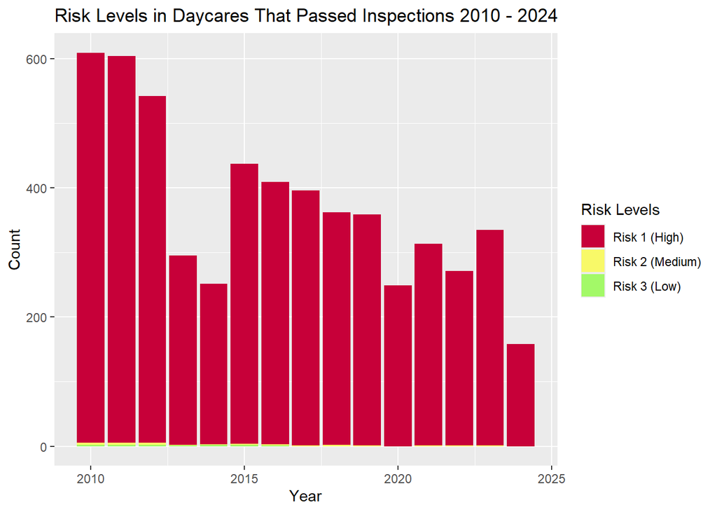

Figure 4: Risk levels in daycares that passed inspections, 2010 to 2024.

```r
# Daycare risk levels throughout the years
csf_select %>%
  filter(Facility_Type == 'Daycare', Results %in% c('Pass', 'Pass w/ Conditions')) %>%
  ggplot(aes(x = Year, fill = Risk)) +
  geom_bar() +
  labs(title = "Risk Levels in Daycares That Passed Inspections 2010 - 2024",
       x = "Year",
       y = "Count") +
  scale_fill_manual("Risk Levels",
                    values = c("Risk 1 (High)" = "#C70039",
                               "Risk 2 (Medium)" = "#f8f968",
                               "Risk 3 (Low)" = "#a3f968"))
```

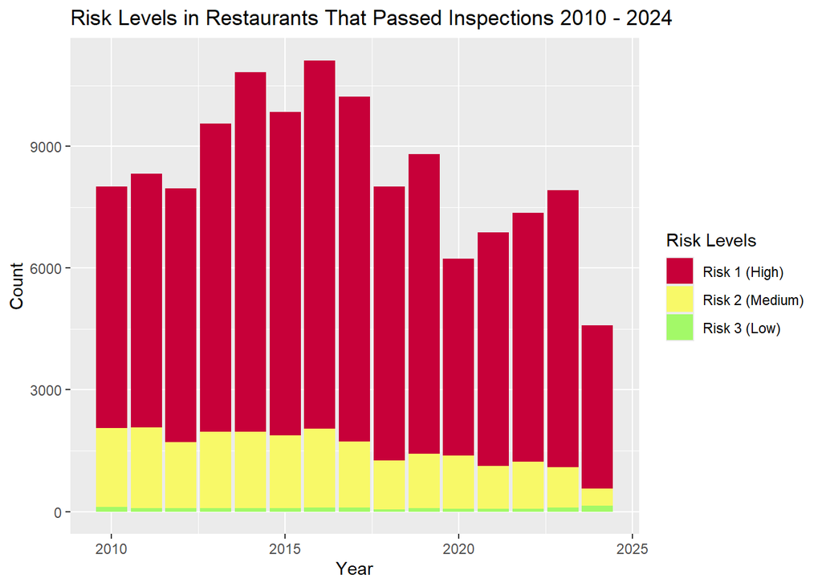

Figure 5: Risk levels in restaurants that passed inspections, 2010 to 2024.

```r
# Restaurants risk levels throughout the years
csf_select %>%
  filter(Facility_Type == 'Restaurant', Results %in% c('Pass', 'Pass w/ Conditions')) %>%
  ggplot(aes(x = Year, fill = Risk)) +
  geom_bar() +
  labs(title = "Risk Levels in Restaurants That Passed Inspections 2010 - 2024",
       x = "Year",
       y = "Count") +
  scale_fill_manual("Risk Levels",
                    values = c("Risk 1 (High)" = "#C70039",
                               "Risk 2 (Medium)" = "#f8f968",
                               "Risk 3 (Low)" = "#a3f968"))
```

#### Correlation Between Risk Rates and Pass Rates

To check whether the rate of any particular risk classification is connected to the overall pass rate of a facility type, I computed yearly rates for Risk 1, Risk 2, and Risk 3, and plotted them against the pass rate.

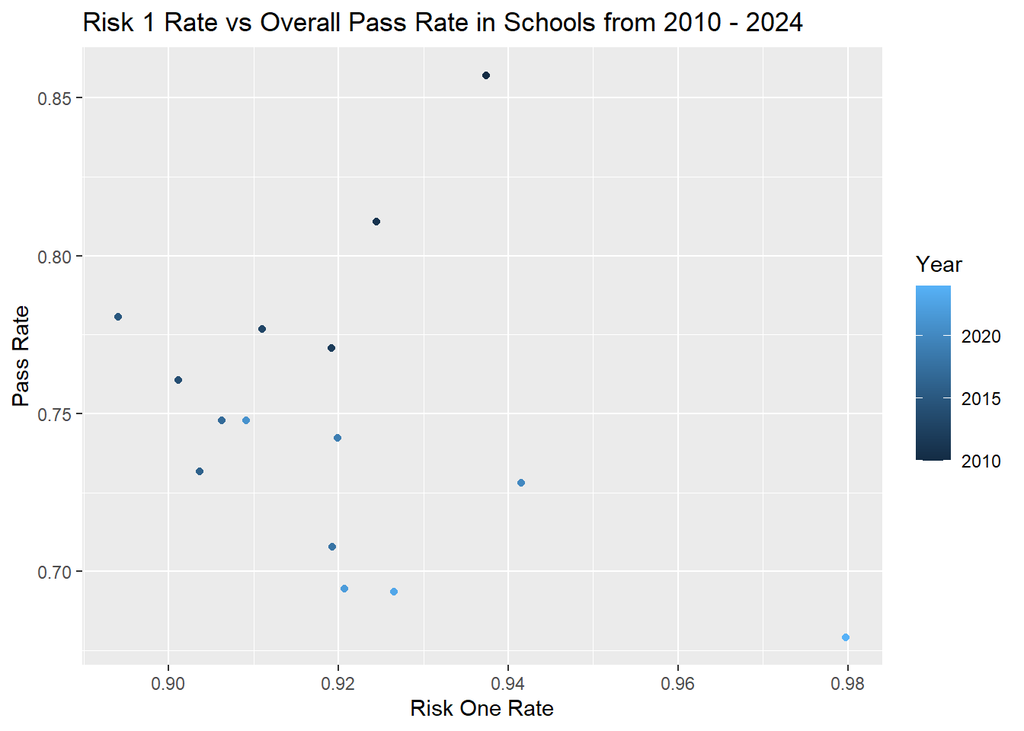

Figure 6: Risk 1 Rate vs. Overall Pass Rate in Schools, 2010 to 2024.

```r
# School: Risk 1 Rate vs Pass Rate
combine_data_risk_pass %>%
  filter(Facility_Type == 'School') %>%
  ggplot(aes(x = Risk_One_Rate, y = Pass_Rate, color = Year)) +
  geom_point() +
  labs(title = "Risk 1 Rate vs Overall Pass Rate in Schools from 2010 - 2024",
       x = 'Risk One Rate',
       y = 'Pass Rate')
```

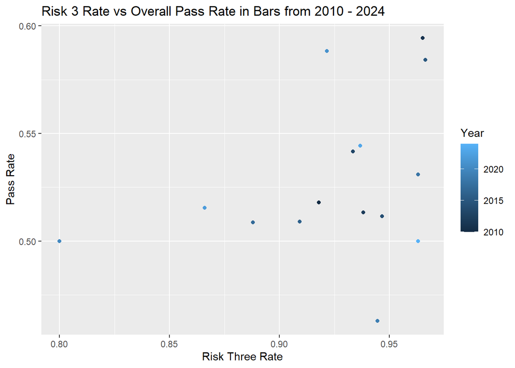

Figure 7: Risk 3 Rate vs. Overall Pass Rate in Bars, 2010 to 2024.

```r
# Bar: Risk 3 Rate vs Pass Rate
combine_data_risk_pass %>%
  filter(Facility_Type == 'Bar') %>%
  ggplot(aes(x = Risk_Three_Rate, y = Pass_Rate, color = Year)) +
  geom_point() +
  labs(title = "Risk 3 Rate vs Overall Pass Rate in Bars from 2010 - 2024",
       x = 'Risk Three Rate',
       y = 'Pass Rate')
```

#### Predicting Pass Rate with a Linear Regression Model

To formally test whether past risk classifications can predict pass rates, a Linear Regression Model was built using Risk 1 Rate, Risk 2 Rate, Risk 3 Rate, Year, and Facility Type as the predictors. The data was first split 80:20 into training and testing sets, and then the same model was evaluated against the full dataset.

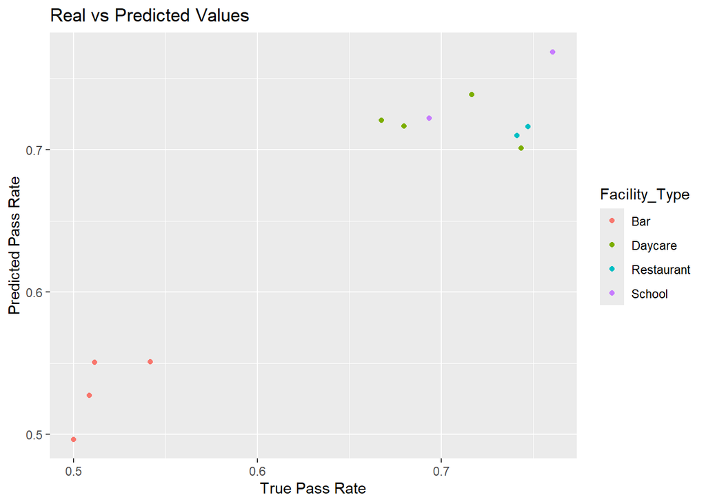

Figure 8: Predicted vs. true pass rates from the linear regression model, colored by facility type.

```r
#splitting the data 80:20 for Testing and Training Data
set.seed(123)
split <- sample.split(combine_data_risk_pass$Pass_Rate, SplitRatio = 0.8)
train_data <- subset(combine_data_risk_pass, split == TRUE)
test_data <- subset(combine_data_risk_pass, split == FALSE)

# Training a Linear model
lr_model <- lm(Pass_Rate ~ Risk_One_Rate + Risk_Two_Rate + Risk_Three_Rate + Year + Facility_Type,
               data = train_data)

# Predicting on the test data
pred <- predict(lr_model, newdata = test_data)
test_data$pred <- pred

# Plotting the results
ggplot(test_data, aes(x = Pass_Rate, y = pred, color = Facility_Type)) +
  geom_point() +
  labs(title = "Real vs Predicted Values",
       x = "True Pass Rate",
       y = "Predicted Pass Rate")
```

```r
# Mean Absolute Error
mae <- mean(abs(test_data$Pass_Rate - pred), na.rm = TRUE)

# R-squared from the 80:20 trained model
r_sqr <- summary(lr_model)$r.squared

# Evaluating on the entire dataset
pred_all_data <- predict(lr_model, newdata = combine_data_risk_pass)
mae_all <- mean(abs(combine_data_risk_pass$Pass_Rate - pred_all_data), na.rm = TRUE)
r_sqr_all <- summary(lm(Pass_Rate ~ Risk_One_Rate + Risk_Two_Rate + Risk_Three_Rate + Year + Facility_Type,
                        data = combine_data_risk_pass))$r.squared

cat("80:20 Model\n",
    "  R-squared: ", round(r_sqr, 4), "\n",
    "  MAE:       ", round(mae, 4), "\n\n",
    "Entire Dataset\n",
    "  R-squared: ", round(r_sqr_all, 4), "\n",
    "  MAE:       ", round(mae_all, 4), "\n",
    sep = "")
```

```
80:20 Model
  R-squared: 0.867
  MAE:       0.0269

Entire Dataset
  R-squared: 0.8799
  MAE:       0.0252
```

#### Chi-Square Test for Independence

The linear model tells us about the strength of a relationship but to confirm that risk classification and inspection result are not independent of one another a Chi-Square Test of Independence was run on the full filtered dataset.

```r
# Chi-Square Test of Independence between Risk and Results
chi_result <- chisq.test(csf_select$Risk, csf_select$Results, correct = FALSE)
chi_result
```

```
    Pearson's Chi-squared test

data:  csf_select$Risk and csf_select$Results
X-squared = 1859.1, df = 18, p-value < 2.2e-16
```

### Discussion

Pulling the linear model and the Chi-Square test together, the hypothesis I went into this project with held up. Past risk classifications and pass rates are strong predictors of future inspection results, and the relationship between risk and result is not something that can be explained away as coincidence.

The model also has clear room to grow. We can use past results to predict future pass rates, but the accuracy of these predictions will increase over time with more data being used to train the model and more factors that effect the pass rate being considered. Things like inspection type, location within the city, violation history, and time since the last inspection are all variables that could meaningfully sharpen the predictions in a future version of this work.

Data driven insights in the food industry can revolutionize the sector when enough attention is given to maintaining high standards for our food.

### Code and Data Availability

To view my project you can access it here: [GitHub Repository](https://github.com/pcigbik)

To look at the original data source you can access it here: [Chicago Food Inspection Data](https://data.cityofchicago.org/Health-Human-Services/Food-Inspections/4ijn-s7e5/about_data)

Please note that this dataset is continuously being updated by the City of Chicago as more inspections data becomes available.

### Acknowledgements

I would like to acknowledge Shaunette Ferguson for mentoring througout this project, Pavithra Dasarakoppalu for helping me with all my technical issues as my TA, and The Coding School alongside Columbia University for giving me this opportunity to learn and grow in the field of Data Science.

### Citations

Government, United States. “Estimates of Foodborne Illness in the United States.” *Centers for Disease Control and Prevention*, Centers for Disease Control and Prevention, 5 Nov. 2018, www.cdc.gov/foodborneburden/index.html.

“Year in Review.” *World Business Chicago*, Chicago Business Bulletin, worldbusinesschicago.com/app/uploads/2023/02/WBCResearch-Center_Year_In_Review_2023.pdf. Accessed 17 Aug. 2024.